# R for Meta-Analysis (MA)

Today, we will be focusing on a basic meta-analysis model for correlations. We will work out of a simulated dataset that I have put together specifically for this demonstration.

First, we need to read in this data and take a look at it:

```r
# install.packages(readxl)
library(readxl)
RMetaData <- read_excel("R Meta-Analysis Data.xlsx")
View(RMetaData)
```

This dataset is a 25x6 matrix, containing the following five variables:

1. [,1] “studyNumber” = An index the study number in our database (K = 25)
2. [,2] “Citation” = A short citation for the study being considered
3. [,3] “rxy” = An effect size estimate (i.e., a correlation between variables X & Y)
4. [,4] “N” = The sample size that was used to estimate ‘rxy’
5. [,5] “mod” = A categorical study-level moderator variable (e.g., 0 = self vs. 1 = other reports of Y)

To begin, let’s consider the average correlation rxy. This represents the unweighted average of ‘rxy’ across the K = 25 studies considered here

```r
mean(RMetaData$rxy)
```

```
[1] 0.1216309
```

We will be working with the ‘metafor’ package today, so let’s install & load it now. You can learn more about this package, here: http://www.metafor-project.org/doku.php

We will also use a function in the ‘MAc’ packages, so let’s get that installed & loaded, too:

```r
# install.packages("metafor")
library(metafor)
# install.packages("MAc")
library(MAc)
```

As a first step in our analyses, we need to compute the sampling variances for each ‘rxy’ The meta-analysis procedure that we will use here weights each ‘rxy’ by the inverse of its sampling variance (1/Sampling Variance).

The logic to this is fairly straightforward:

- Studies with larger Ns are more precise estimates of the parameter
- Studies with larger Ns also have smaller sampling variances
- Therefore, by weighting each study by the inverse of its sampling variance, larger N studies get more “credit” in our model.

The ‘var_r’ function in the MAc computes this for us simply:

```r
#Variance
RMetaData$var_rxy <- var_r(RMetaData$rxy, RMetaData$N)
```

With our sampling variances computed, let’s start by specifying a simple meta-analysis model The basic function for a random-effects meta-analysis in ‘metafor’ is ‘rma’ We need to supply specify several arguments to this function:

1. ‘yi’ = the effect to be meta-analyzed, in our case ‘rxy’
2. ‘vi’ = the sampling variance of the effect to be analyzed, in our case ‘var_rxy’
3. ‘data’ = our dataframe, ‘RMetaData’
4. ‘method’ = the estimation method, in our case ‘REML’ for “restricted maximum likelihood”

```r
meta_mod1 = rma(yi = rxy, vi = var_rxy, data=RMetaData, method="REML")
summary(meta_mod1)
```

```
Random-Effects Model (k = 25; tau^2 estimator: REML)

  logLik  deviance       AIC       BIC      AICc
 27.8047  -55.6094  -51.6094  -49.2533  -51.0380

tau^2 (estimated amount of total heterogeneity): 0.0012 (SE = 0.0013)
tau (square root of estimated tau^2 value):      0.0348
I^2 (total heterogeneity / total variability):   24.83%
H^2 (total variability / sampling variability):  1.33

Test for Heterogeneity:
Q(df = 24) = 28.5833, p-val = 0.2362

Model Results:

estimate      se     zval    pval   ci.lb   ci.ub
  0.1495  0.0146  10.2666  <.0001  0.1209  0.1780  ***

---
Signif. codes:  0 ‘***’ 0.001 ‘**’ 0.01 ‘*’ 0.05 ‘.’ 0.1 ‘ ’ 1
```

Taking a look at this output, we learn several important things:

1. The average inverse-variance weighted effect is about rxy = .15 [Note: How does this compare to our original estimate of the average that we took earlier?]
2. The 95% CI around this estimate does not include zero, so we are confident that it is statistically significantly different from zero (p < .05)

We can also get a “forest plot” to visualize this effect against the K = 25 primary studies

Note: there is some aparent variability in the K = 25 effects that comprise our model

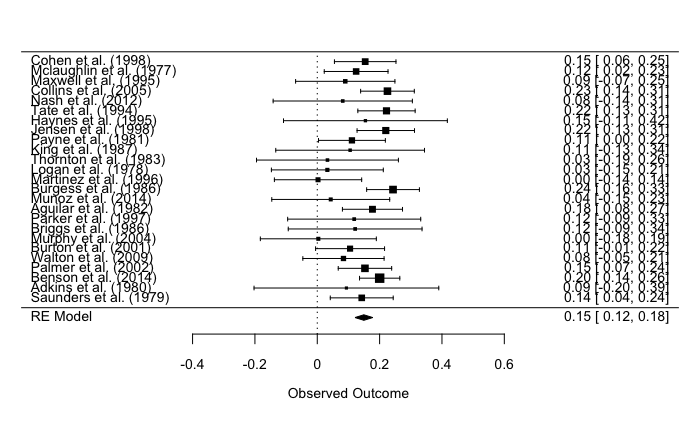

```r
forest(meta_mod1, slab=RMetaData$Citation)
```

So, with this in mind, let’s consider formal tests of moderation. Specifically, let’s test whether there are differences based upon the source of Y (0 = self report, 1 = other report)

```r
meta_mod2 = rma(yi = rxy, vi = var_rxy, mods= ~ factor(mod)-1, data=RMetaData, method="REML")
summary(meta_mod2)
```

[output not shown]

From this output, we learn several additional things: